# Practical Session 4

## Smoothing and Trends

```r
rm(list=ls())
# Install pacman if not installed already, and activate it
if (!require("pacman")) install.packages("pacman")

# Install, update and activate libraries
pacman::p_load(
  here,
  rio,
  skimr,
  tsibble,
  ISOweek,
  slider,    # for rolling means
  imputeTS,  #necessary? /skb
  pander,
  tidyverse
)


# Create tsa_theme
tsa_theme <- theme_bw() +
        theme(
            plot.title = element_text(face = "bold",
                                      size = 12),
            legend.background = element_rect(fill = "white",
                                             size = 4,
                                             colour = "white"),
            # legend.justification = c(0, 1),
            legend.position = "bottom",
            panel.grid.minor = element_blank()
        )
```

## Mortality Surveillance data in Spain

The Spanish daily mortality monitoring system is run by the National Centre for Epidemiology in Madrid and gathers data from a stable number of municipalities around the country with a computerised death register; the system is representative of the population of Spain and was developed in 2004 with the objective of identifying exceedances in mortality during the summer period. Data since 2000 were collected retrospectively.

Sessions 4-7 and 11 use data from this mortality surveillance system. Session 10 uses data from the same system, but for only one autonomous community in Spain (Aragón).

## Expected learning outcomes

By the end of the session, participants should be able to:

Describe, test and fit a trend in surveillance data (simple smoothing and regression);

Assess and interpret the significance of trend in surveillance data.

You are provided with a dataset in R (`mortagg.Rdata`) which includes variables on week, year, total number of deaths (`cases`), and population, as well as number of deaths and population among males and females separately.

## Task 4.1

**Assess visually how the total registered number of deaths has been behaving in the years with available data. Save any changes to a new dataset named `mortality_agg`.**

**Discuss your results with your peers.**

**How would you proceed in analysing your data to further understand how mortality behaves?**

## Task 4.1.1 (Optional)

**Would you reach the same conclusions if you were exploring mortality for males and females separately? Discuss with your peers.**

### Moving average and direct statistical modelling of trends

Moving averages are simple methods to visualise the general trend of a series after removing some of the random day-to-day variation by smoothing the data. This allows you to browse your data for periodicity and observe the general trend. In other words, smoothing the data may remove “noise” from your time series and can facilitate visual interpretation.

Moving averages model a time series by calculating the numerical mean of the values adjacent to it. It is calculated for each observation, moving along the time axis: e.g. at each time $t$ and for a window of 5 time units, one way of calculating the moving average is by using the observations at $t-2$, $t-1$, $t$, $t+1$ and $t+2$.

### Regression

Using regression methods against the time variable is a simple and familiar way to look at trends and test the slope with the Wald test provided in the output. The kind of regression and interpretation you will use depends on the nature of your dependent variable – in this case, the number (count) of registered deaths.

## Task 4.2

Assess visually the existence of a long-term trend and periodicity in the `mortality_agg` dataset by using smoothing techniques. Where would you centre the smoothing window and why? What is the effect of using different smoothing window centring options?

## Task 4.3

Assess statistically whether the registered number of deaths has been stable in the years available in your dataset. How well can you model the registered number of deaths by assessing only the long-term trend?

## Task 4.3.1 (Optional)

How could you take the – potentially changing – population of Spain into account in your analyses? Data on population are provided in the file `population.xls`.

## Task 4.3.2 (Optional)

If you are confident with addressing the tasks above and still have enough time, follow the same procedure with the `dis1` dataset. Which regression models (other than linear regression) may be relevant in this example?

## Help for Task 4.1

```r
load(here("data", "mortagg2.Rdata"))
```

Inspect the data.

```r
str(mortagg)
```

```
## 'data.frame':    521 obs. of  8 variables:
##  $ cases_m: num  4207 4409 4229 4252 4196 ...
##  $ cases_f: num  4019 4264 4122 3837 3976 ...
##  $ cases  : num  8226 8673 8351 8089 8172 ...
##  $ year   : num  2010 2010 2010 2010 2010 2010 2010 2010 2010 2010 ...
##  $ week   : num  1 2 3 4 5 6 7 8 9 10 ...
##  $ pop    : num  46486621 46486621 46486621 46486621 46486621 ...
##  $ pop_f  : num  23504349 23504349 23504349 23504349 23504349 ...
##  $ pop_m  : num  2.3e+07 2.3e+07 2.3e+07 2.3e+07 2.3e+07 ...
```

```r
summary(mortagg)
```

```
##     cases_m        cases_f         cases            year           week
##  Min.   :3276   Min.   :2941   Min.   : 6316   Min.   :2010   Min.   : 1.0
##  1st Qu.:3648   1st Qu.:3464   1st Qu.: 7106   1st Qu.:2012   1st Qu.:14.0
##  Median :3839   Median :3684   Median : 7510   Median :2015   Median :27.0
##  Mean   :3969   Mean   :3818   Mean   : 7788   Mean   :2014   Mean   :26.6
##  3rd Qu.:4194   3rd Qu.:4047   3rd Qu.: 8217   3rd Qu.:2017   3rd Qu.:40.0
##  Max.   :5597   Max.   :5877   Max.   :11471   Max.   :2019   Max.   :53.0
##       pop               pop_f              pop_m
##  Min.   :46418884   Min.   :23504349   Min.   :22806445
##  1st Qu.:46486621   1st Qu.:23612439   1st Qu.:22831107
##  Median :46497393   Median :23621034   Median :22889600
##  Mean   :46608292   Mean   :23669979   Mean   :22938313
##  3rd Qu.:46712650   3rd Qu.:23719207   3rd Qu.:23016783
##  Max.   :46918951   Max.   :23902168   Max.   :23099009
```

```r
view(mortagg)
```

```r
skimr::skim(mortagg) # does this give any more informaton than summary?
```

Data summary

| Name | mortagg |
| --- | --- |
| Number of rows | 521 |
| Number of columns | 8 |
| _______________________ |  |
| Column type frequency: |  |
| numeric | 8 |
| ________________________ |  |
| Group variables | None |

**Variable type: numeric**

| skim_variable | n_missing | complete_rate | mean | sd | p0 | p25 | p50 | p75 | p100 | hist |
| --- | --- | --- | --- | --- | --- | --- | --- | --- | --- | --- |
| cases_m | 0 | 1 | 3.9692e+03 | 454.44 | 3276 | 3648 | 3839 | 4194 | 5597 | ▇▇▃▁▁ |
| cases_f | 0 | 1 | 3.8185e+03 | 544.44 | 2941 | 3464 | 3684 | 4047 | 5877 | ▆▇▃▁▁ |
| cases | 0 | 1 | 7.7877e+03 | 992.14 | 6316 | 7106 | 7510 | 8217 | 11471 | ▇▇▃▁▁ |
| year | 0 | 1 | 2.0145e+03 | 2.87 | 2010 | 2012 | 2015 | 2017 | 2019 | ▇▇▇▇▇ |
| week | 0 | 1 | 2.6550e+01 | 15.05 | 1 | 14 | 27 | 40 | 53 | ▇▇▇▇▇ |
| pop | 0 | 1 | 4.6608e+07 | 163065.99 | 46418884 | 46486621 | 46497393 | 46712650 | 46918951 | ▇▁▅▂▂ |
| pop_f | 0 | 1 | 2.3670e+07 | 102454.81 | 23504349 | 23612439 | 23621034 | 23719207 | 23902168 | ▂▇▆▂▂ |
| pop_m | 0 | 1 | 2.2938e+07 | 100399.88 | 22806445 | 22831107 | 22889600 | 23016783 | 23099009 | ▇▅▁▇▅ |

Create a time series object with `tsibble`, using the total case counts and plot it.

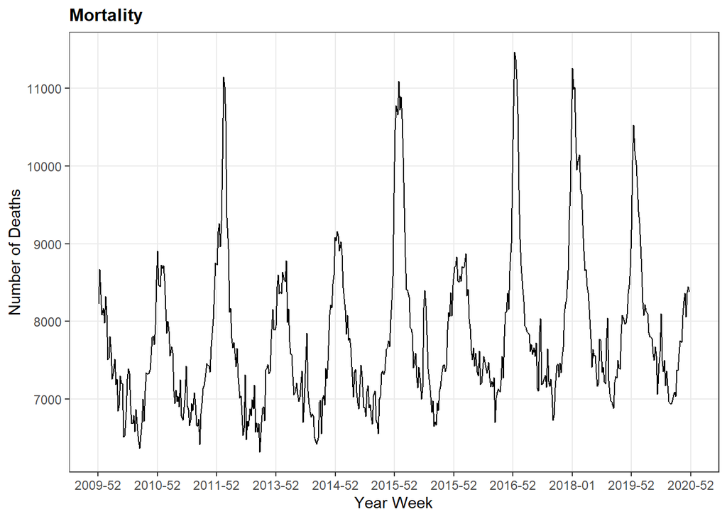

```r
mortz <-
  mortagg %>%
  mutate(date_index = make_yearweek(year = year, week = week)) %>%
  as_tsibble(index = date_index)


ggplot(data = mortz) +
  geom_line(mapping = aes(x = date_index, y = cases)) +
  scale_x_yearweek(date_labels = "%Y-%W", date_breaks = "1 year") +
  labs(x = "Year Week", y = "Number of Deaths", title = "Mortality") +
  tsa_theme
```

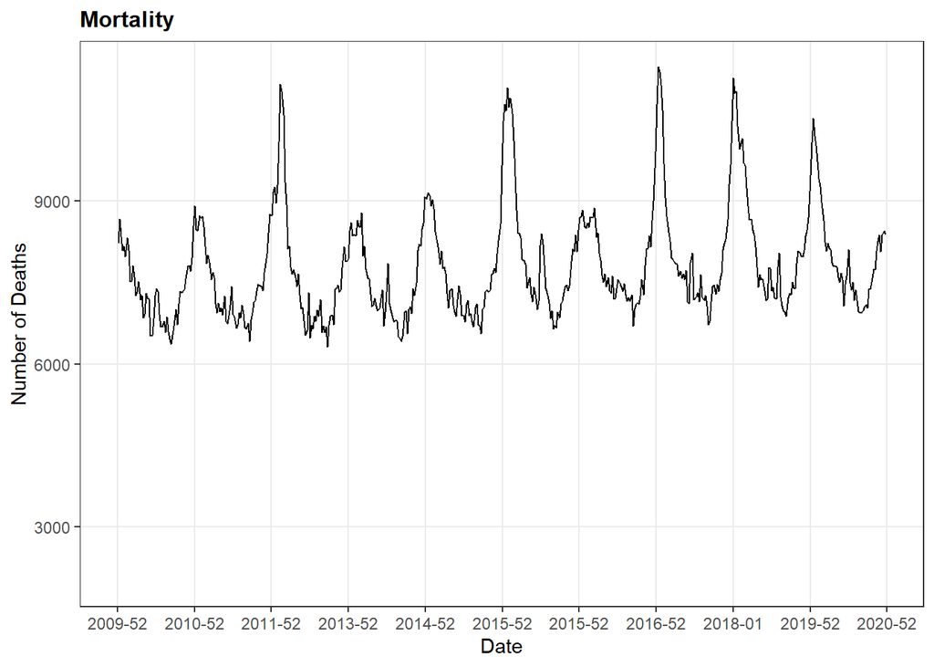

```r
## Adjusting y-axis scale
ggplot(data = mortz) +
  geom_line(mapping = aes(x = date_index, y = cases)) +
  scale_x_yearweek(date_labels = "%Y-%W", date_breaks = "1 year") +
  scale_y_continuous(limits = c(2000, NA)) +
  labs(x = "Date", y = "Number of Deaths", title = "Mortality") +
  tsa_theme
```

## Help for Task 4.1.1

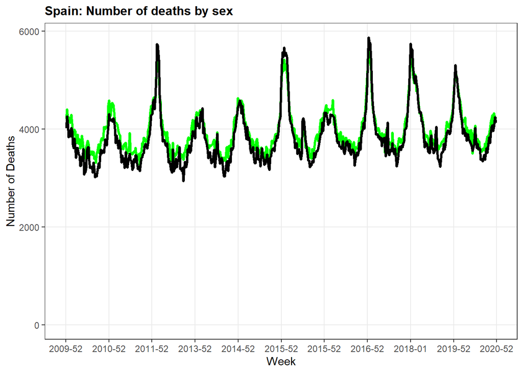

```r
## Men and Women
ggplot(data = mortz) +
  geom_line(mapping = aes(x = date_index, y = cases_m),
        colour = "green",
        lwd=1.1) +
  geom_line(mapping = aes(x = date_index, y = cases_f),
        colour = "black",
        lwd=1.1) +
  scale_x_yearweek(date_labels = "%Y-%W", date_breaks = "1 year") +
  scale_y_continuous(limits = c(0, NA)) +
  labs(x = "Week", y = "Number of Deaths", title = "Spain: Number of deaths by sex") +
  tsa_theme
```

## Help for Task 4.2

According to the `slider` package description, `slider` is a package for rolling windows analysis. It means that a given function is repeatedly applied to different “windows” of your data as you step through it. Typical examples of applications of rolling window window functions include moving averages or cumulative sums.

The `slider` family of functions from the `slider` package contains a collection of functions specifically designed to compute a given operation on a rolling window. An introduction vignette for slider can be found by running the following command: `vignette("slider")`

For each record, create the following various types of moving average.

- `MA5a`: the 5-week moving average, centred on cases.
- `MA5b`: the 5-week moving average of cases and the 4 previous weeks.
- `MA5c`: the 5-week moving average of the 5 previous weeks.

Compare results.

```r
mortzma <-
  mortz %>%
  mutate(
    MA5a = slide_index_dbl(
      .x = cases,
      .i = date_index,
      .f = mean,
      na.rm = TRUE,
      .before = 2,
      .after = 2,
      .complete = TRUE
    ),
    MA5b = slide_index_dbl(
      .x = cases,
      .i = date_index,
      .f = mean,
      na.rm = TRUE,
      .before = 4,
      .complete = TRUE
    ),
    MA5c = slide_index_dbl(
      .x = cases,
      .i = date_index,
      .f = function(x) mean(x[-6], na.rm = TRUE),
      .before = 5,
      .complete = TRUE
    )
  )

# view first 10 lines of data
head(mortzma, 10)
```

```
## # A tsibble: 10 x 12 [1W]
##    cases_m cases_f cases  year  week    pop  pop_f  pop_m date_index  MA5a  MA5b
##      <dbl>   <dbl> <dbl> <dbl> <dbl>  <dbl>  <dbl>  <dbl>     <week> <dbl> <dbl>
##  1    4207    4019  8226  2010     1 4.65e7 2.35e7 2.30e7   2010 W01   NA    NA
##  2    4409    4264  8673  2010     2 4.65e7 2.35e7 2.30e7   2010 W02   NA    NA
##  3    4229    4122  8351  2010     3 4.65e7 2.35e7 2.30e7   2010 W03 8302.   NA
##  4    4252    3837  8089  2010     4 4.65e7 2.35e7 2.30e7   2010 W04 8253.   NA
##  5    4196    3976  8172  2010     5 4.65e7 2.35e7 2.30e7   2010 W05 8183  8302.
##  6    4127    3854  7981  2010     6 4.65e7 2.35e7 2.30e7   2010 W06 8131. 8253.
##  7    4294    4028  8322  2010     7 4.65e7 2.35e7 2.30e7   2010 W07 8015  8183
##  8    4121    3968  8089  2010     8 4.65e7 2.35e7 2.30e7   2010 W08 7887. 8131.
##  9    3824    3687  7511  2010     9 4.65e7 2.35e7 2.30e7   2010 W09 7853. 8015
## 10    3921    3612  7533  2010    10 4.65e7 2.35e7 2.30e7   2010 W10 7710. 7887.
## # ℹ 1 more variable: MA5c <dbl>
```

The `slide_index_dbl` is a `slider` package function designed to run a pre-specified function on a rolling window of a numeric (`_dbl`) variable, ordered by an index time (date or date-time) variable. A full description of this function can be found by running the following command: `?slide_index_dbl`

The `.x` argument provides the vector with the numbers that will be used for computation.

The `.i` argument defines the vector with the time variable that will be used for ordering the data.

The `.f` argument indicates the function that will be used to perform the intended computations. In this case, an arithmetic mean computation is carried out by using the `mean` function. The `na.rm = TRUE` is a varying argument included as a `...` argument of `slide_index_dbl`. (Run the expression `args("slide_index_dbl")` and take notice on the position/sequence of this function’s arguments).

The `.before` argument defines the number of observations before the central time point of a given time window to use in the rolling window computation. In the example above for a 5 time points centred moving average, in `MA5a`, 2 observations are used before the central point, and 2 observations are used after it, using the `.after` argument.

The `complete` argument indicates where the computation should be carried in rolling windows that have complete observations.

We applied a more complicated function to compute `MA5c`, taking a backwards moving window of six values but omitting the latest value (current time point) from the calculation of the average.

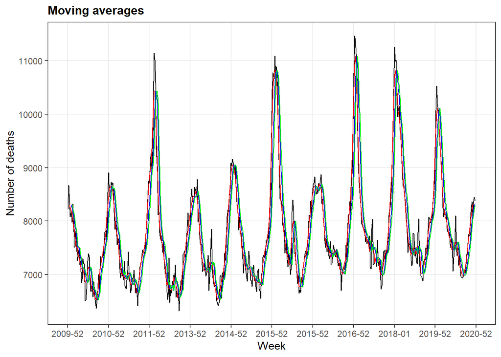

```r
## wide format dataset ---
ggplot(data = mortzma, mapping = aes(x = date_index)) +
  geom_line(mapping = aes(y = cases), colour = "black") +
  geom_line(mapping = aes(y = MA5a), colour = "red") +
  geom_line(mapping = aes(y = MA5b), colour = "blue") +
  geom_line(mapping = aes(y = MA5c), colour = "green") +
  scale_x_yearweek(date_labels = "%Y-%W",
                   date_breaks = "1 year") +
  labs(x = "Week",
       y = "Number of deaths",
       title = "Moving averages") +
  tsa_theme
```

We observe that the calculation is similar across these various methods, but is not aligned to the series in the same way. `MA5a` is centred in the middle of the period used to calculate the mean. `MA5b` is placed at the end of the period. `MA5c` is placed one step forward (smoothing functions can be used for forecasting the following point). The “models” provided are similar for a 5-week window, but the *lag* is different.

Moving average is only one way of smoothing. Other ways of smoothing the data to get a general idea of the trend include, for example, LOESS (locally estimated scatterplot smoothing) smoothing, where the contribution of surrounding observations is weighted, i.e. it is not the arithmetical mean for each set (window) of observations.

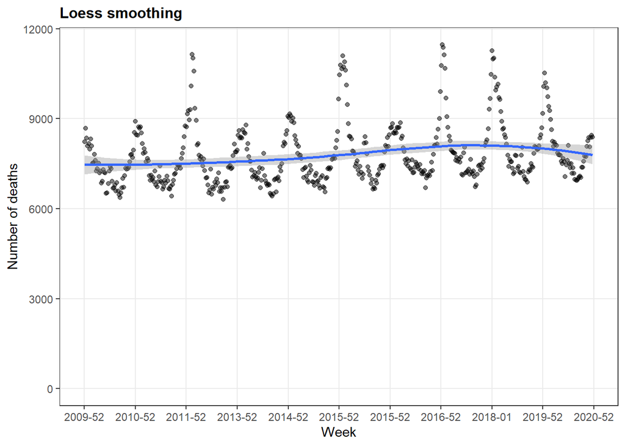

```r
ggplot(mortz, mapping = aes(x = date_index, y = cases)) +
  geom_point(alpha = 0.5) +
  geom_smooth(se = TRUE) +
  scale_x_yearweek(date_labels = "%Y-%W",
                   date_breaks = "1 year") +
  scale_y_continuous(limits = c(0, NA)) +
  labs(x = "Week",
       y = "Number of deaths",
       title = "Loess smoothing") +
  tsa_theme
```

The `stat_smooth` provides a smoothing curve using a LOESS method. We can change the degree of smoothing by adding a `span` option. The `span` controls the amount of smoothing for the default loess smoother; smaller numbers produce wigglier lines, and larger numbers produce smoother lines.

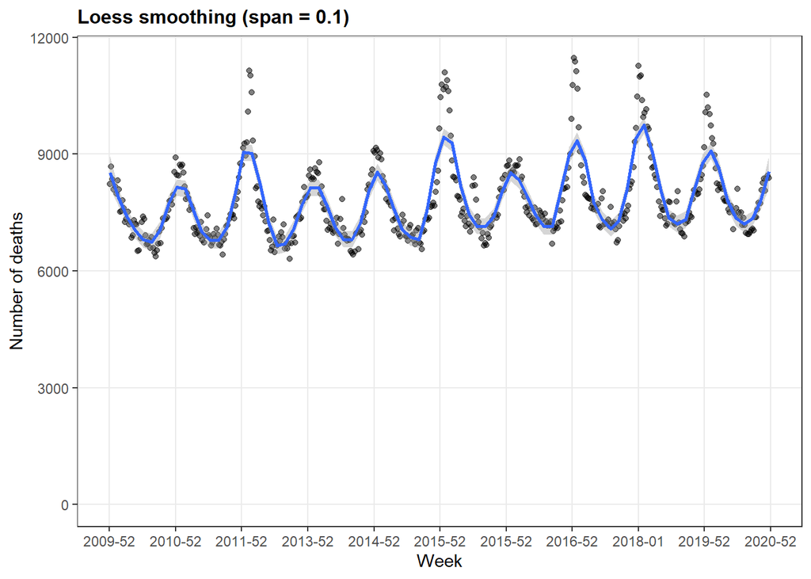

```r
ggplot(data = mortz, mapping = aes(x = date_index, y = cases)) +
  geom_point(alpha = 0.5) +
  stat_smooth(se = TRUE, span=0.1) +
  scale_x_yearweek(date_labels = "%Y-%W", date_breaks = "1 year") +
  scale_y_continuous(limits = c(0, NA)) +
  labs(x = "Week", y = "Number of deaths", title = "Loess smoothing (span = 0.1)") +
  tsa_theme
```

To better observe the general trend, we need to find the length of the moving average that will erase the seasonal component. Various lengths can be tried; here we have used 25, 51 and 103.

```r
mortzma2 <-
  mortz %>%
  mutate(
    MA25 = slide_index_dbl(
      .x = cases,
      .i = date_index,
      .f = mean,
      na.rm = TRUE,
      .before = 24,
      .complete = TRUE
    ),
    MA51 = slide_index_dbl(
      .x = cases,
      .i = date_index,
      .f = mean,
      na.rm = TRUE,
      .before = 50,
      .complete = TRUE
    ),
    MA103 = slide_index_dbl(
      .x = cases,
      .i = date_index,
      .f = mean,
      na.rm = TRUE,
      .before = 102,
      .complete = TRUE
    )
  )


## Visually inspect data
slice(mortzma2, 20:30)
```

```
## # A tsibble: 11 x 12 [1W]
##    cases_m cases_f cases  year  week    pop  pop_f  pop_m date_index  MA25  MA51
##      <dbl>   <dbl> <dbl> <dbl> <dbl>  <dbl>  <dbl>  <dbl>     <week> <dbl> <dbl>
##  1    3867    3436  7303  2010    20 4.65e7 2.35e7 2.30e7   2010 W20   NA     NA
##  2    3758    3446  7204  2010    21 4.65e7 2.35e7 2.30e7   2010 W21   NA     NA
##  3    3605    3595  7200  2010    22 4.65e7 2.35e7 2.30e7   2010 W22   NA     NA
##  4    3440    3076  6516  2010    23 4.65e7 2.35e7 2.30e7   2010 W23   NA     NA
##  5    3407    3124  6531  2010    24 4.65e7 2.35e7 2.30e7   2010 W24   NA     NA
##  6    3632    3201  6833  2010    25 4.65e7 2.35e7 2.30e7   2010 W25 7531.    NA
##  7    3690    3567  7257  2010    26 4.65e7 2.35e7 2.30e7   2010 W26 7492.    NA
##  8    3764    3625  7389  2010    27 4.65e7 2.35e7 2.30e7   2010 W27 7441.    NA
##  9    3697    3638  7335  2010    28 4.65e7 2.35e7 2.30e7   2010 W28 7400.    NA
## 10    3570    3349  6919  2010    29 4.65e7 2.35e7 2.30e7   2010 W29 7353.    NA
## 11    3476    3209  6685  2010    30 4.65e7 2.35e7 2.30e7   2010 W30 7294.    NA
## # ℹ 1 more variable: MA103 <dbl>
```

```r
slice(mortzma2, 45:55)
```

```
## # A tsibble: 11 x 12 [1W]
##    cases_m cases_f cases  year  week    pop  pop_f  pop_m date_index  MA25  MA51
##      <dbl>   <dbl> <dbl> <dbl> <dbl>  <dbl>  <dbl>  <dbl>     <week> <dbl> <dbl>
##  1    3771    3563  7334  2010    45 4.65e7 2.35e7 2.30e7   2010 W45 6891.   NA
##  2    3817    3561  7378  2010    46 4.65e7 2.35e7 2.30e7   2010 W46 6898.   NA
##  3    4049    3516  7565  2010    47 4.65e7 2.35e7 2.30e7   2010 W47 6912.   NA
##  4    4001    3794  7795  2010    48 4.65e7 2.35e7 2.30e7   2010 W48 6963.   NA
##  5    4058    3754  7812  2010    49 4.65e7 2.35e7 2.30e7   2010 W49 7015.   NA
##  6    4034    3668  7702  2010    50 4.65e7 2.35e7 2.30e7   2010 W50 7049.   NA
##  7    4061    3892  7953  2010    51 4.65e7 2.35e7 2.30e7   2010 W51 7077. 7303.
##  8    4484    4056  8540  2010    52 4.65e7 2.35e7 2.30e7   2010 W52 7123. 7309.
##  9    4593    4315  8908  2011     1 4.67e7 2.36e7 2.30e7   2011 W01 7186. 7314.
## 10    4276    4194  8470  2011     2 4.67e7 2.36e7 2.30e7   2011 W02 7248. 7316.
## 11    4271    4175  8446  2011     3 4.67e7 2.36e7 2.30e7   2011 W03 7319. 7323.
## # ℹ 1 more variable: MA103 <dbl>
```

```r
slice(mortzma2, 95:105)
```

```
## # A tsibble: 11 x 12 [1W]
##    cases_m cases_f cases  year  week    pop  pop_f  pop_m date_index  MA25  MA51
##      <dbl>   <dbl> <dbl> <dbl> <dbl>  <dbl>  <dbl>  <dbl>     <week> <dbl> <dbl>
##  1    3824    3513  7337  2011    43 4.67e7 2.36e7 2.30e7   2011 W43 6919. 7420.
##  2    3818    3643  7461  2011    44 4.67e7 2.36e7 2.30e7   2011 W44 6936. 7423.
##  3    3737    3698  7435  2011    45 4.67e7 2.36e7 2.30e7   2011 W45 6958. 7424.
##  4    3789    3644  7433  2011    46 4.67e7 2.36e7 2.30e7   2011 W46 6965. 7421.
##  5    3744    3602  7346  2011    47 4.67e7 2.36e7 2.30e7   2011 W47 6987. 7412.
##  6    3971    3708  7679  2011    48 4.67e7 2.36e7 2.30e7   2011 W48 7025. 7410.
##  7    4025    3824  7849  2011    49 4.67e7 2.36e7 2.30e7   2011 W49 7063. 7413.
##  8    4148    3882  8030  2011    50 4.67e7 2.36e7 2.30e7   2011 W50 7102. 7414.
##  9    4354    4054  8408  2011    51 4.67e7 2.36e7 2.30e7   2011 W51 7141. 7411.
## 10    4476    4277  8753  2011    52 4.67e7 2.36e7 2.30e7   2011 W52 7214. 7408.
## 11    4425    4304  8729  2012     1 4.68e7 2.37e7 2.31e7   2012 W01 7289. 7413.
## # ℹ 1 more variable: MA103 <dbl>
```

You can use `View` to examine the first rows of `mortzma2.`

```r
View(mortzma2)
```

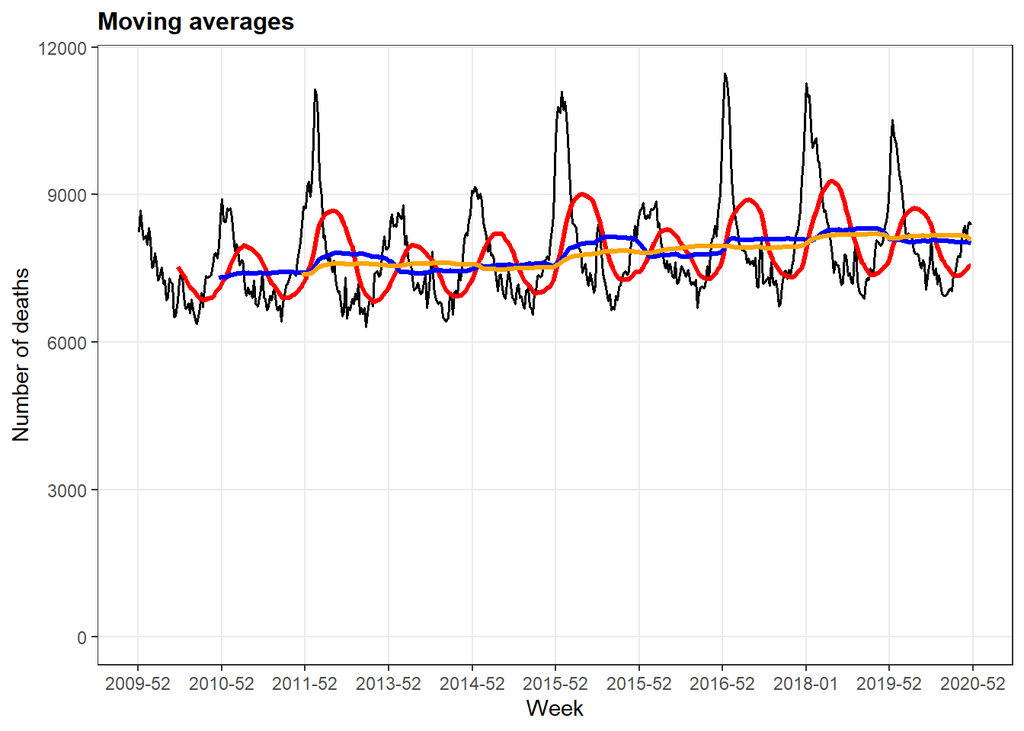

```r
## wide format dataset ---
ggplot(mortzma2, mapping = aes(x = date_index)) +
  geom_line(mapping = aes(y = cases), colour = "black", lwd=0.7) +
  geom_line(mapping = aes(y = MA25), colour = "red", lwd=1.1) +
  geom_line(mapping = aes(y = MA51), colour = "blue", lwd=1.1) +
  geom_line(mapping = aes(y = MA103), colour = "orange", lwd=1.1) +
  scale_x_yearweek(date_labels = "%Y-%W",
                   date_breaks = "1 year") +
  scale_y_continuous(limits = c(0, NA)) +
  labs(x = "Week",
       y = "Number of deaths",
       title = "Moving averages") +
  tsa_theme
```

Comment on the lines provided by the different smoothing windows. Which one do you think is the best for eliminating seasonality? What would happen if you used an even greater window?

## Help for Task 4.3

Using regression against time is a very simple way to look at the trends and test the slope with the Wald test provided.

We will use the `glm` function to fit a linear Poisson regression model.

For the regression you will need to create an index variable from the year and week (consecutive number of week).

```r
mortz <-
  mortz %>%
  ungroup() %>%
  mutate(index = seq.int(from = 1, to = nrow(.)))

mort_poissontrend <- glm(
  formula = cases ~ index,
  family = "poisson",
  data = mortz
)
```

Check model results.

```r
summary(mort_poissontrend)
```

```
##
## Call:
## glm(formula = cases ~ index, family = "poisson", data = mortz)
##
## Coefficients:
##             Estimate Std. Error z value Pr(>|z|)
## (Intercept) 8.91e+00   1.01e-03  8850.2   <2e-16 ***
## index       1.89e-04   3.30e-06    57.4   <2e-16 ***
## ---
## Signif. codes:  0 '***' 0.001 '**' 0.01 '*' 0.05 '.' 0.1 ' ' 1
##
## (Dispersion parameter for poisson family taken to be 1)
##
##     Null deviance: 62509  on 520  degrees of freedom
## Residual deviance: 59215  on 519  degrees of freedom
## AIC: 64841
##
## Number of Fisher Scoring iterations: 4
```

Variables in R models are specified using notation along the lines of `response_variable ~ explanatory_variable_1 + explanatory_variable_2` etc. Check the material from the MVA module. A more detailed explanation of how to build model formulas in R can also be found in the *Details* section of the help page of the `formula` function: `?stats::formula`.

`summary`, when given the results of fitting a regression model, will provide a summary of the fitted trend and associated statistics.

Identify and interpret the intercept and the trend. In a Poisson model on the log(y), the coefficient needs to be exponentiated in order to interpret it for the output y (that is, the original y without the log).

Plot the fitted values against the observed ones.

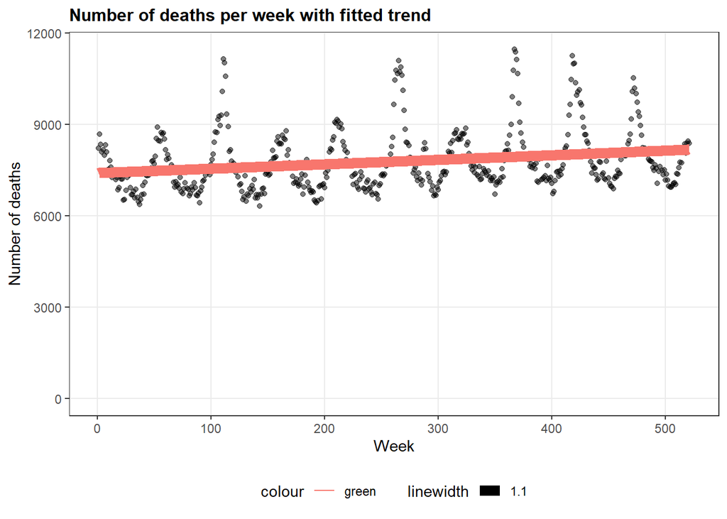

```r
ggplot(data = mortz, mapping = aes(x = index)) +
  geom_point(mapping = aes(y = cases), alpha = 0.5) +
  geom_line(mapping = aes(y = fitted(mort_poissontrend), colour = "green", lwd=1.1)) +
  scale_y_continuous(limits = c(0, NA)) +
  labs(x = "Week", y = "Number of deaths", title = "Number of deaths per week with fitted trend") +
  tsa_theme
```

Could you have used a regression technique other than linear regression? What are the advantages and disadvantages of using linear regression when modelling numbers of cases of a disease?

## Help for Task 4.3.1

```r
# Function to tidy glm regression output
glmtidy <- function(x, caption = "") {
  pander::pander(
    broom::tidy(x,
      exponentiate = TRUE,
      conf.int = TRUE,
      options(digits = 5)
    ),
    caption = caption
  )
}

# Function to tidy glm regression statistics
glmstats <- function(x) {
  pander::pander(broom::glance(x))
}
```

To take the population into account, we need to include the population in the model. This is done by adding a term called offset(). The parameter beta for the offset, in this case for the population, will be forced to be 1; in other words, the offset will not affect the outcome. The advantage is that we can interpret the IRR of time in terms of mortality rate = cases/population.

```r
mort_poissontrend_pop <- glm(cases ~  index + offset(log(pop)),
  data = mortz,
  family = "poisson"
)

summary(mort_poissontrend_pop)
```

```
##
## Call:
## glm(formula = cases ~ index + offset(log(pop)), family = "poisson",
##     data = mortz)
##
## Coefficients:
##              Estimate Std. Error z value Pr(>|z|)
## (Intercept) -8.75e+00   1.01e-03 -8691.7   <2e-16 ***
## index        1.86e-04   3.30e-06    56.5   <2e-16 ***
## ---
## Signif. codes:  0 '***' 0.001 '**' 0.01 '*' 0.05 '.' 0.1 ' ' 1
##
## (Dispersion parameter for poisson family taken to be 1)
##
##     Null deviance: 62588  on 520  degrees of freedom
## Residual deviance: 59399  on 519  degrees of freedom
## AIC: 65025
##
## Number of Fisher Scoring iterations: 4
```

```r
# Trend in the original scale of the outcome cases (deaths) wit 95% confidence intervals.
exp(cbind(Estimate=mort_poissontrend_pop$coef, confint(mort_poissontrend_pop)))*1000
```

```
##               Estimate      2.5 %     97.5 %
## (Intercept)    0.15909    0.15878    0.15941
## index       1000.18634 1000.17987 1000.19280
```

```r
#glmtidy(mort_poissontrend_pop)
```

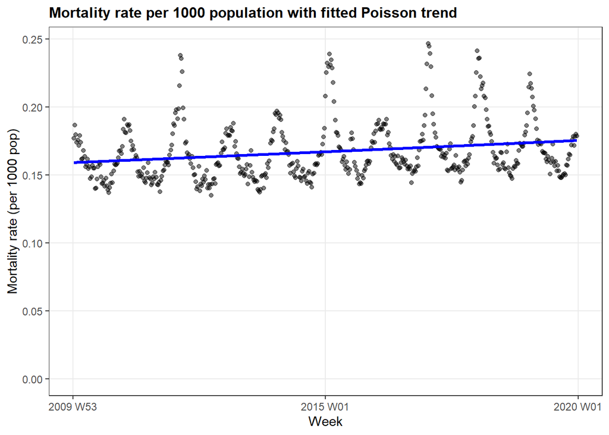

```r
mortz<- mortz %>%
  mutate(
    mortality_rate = cases/pop*1000
  )

ggplot(data = mortz, mapping = aes(x = date_index)) +
  geom_point(mapping = aes(y = mortality_rate), alpha = 0.5) +
  geom_line(mapping = aes(y = fitted(mort_poissontrend_pop)/pop*1000), colour = "blue", lwd=1.1) +
  scale_y_continuous(limits = c(0, NA)) +
  labs(
    x = "Week", y = "Mortality rate (per 1000 pop)",
    title = "Mortality rate per 1000 population with fitted Poisson trend"
  ) +
  tsa_theme
```

## Help for Task 4.3.2

HAVE NOT TRIED THIS ONE OUT.

You can use the salmonellosis example (`dis1`) to see how an exponential trend might fit the data better.

```r
#source("src/tidyverse/session_4.R")
```

For the regression you will still need to create a date variable from the year and week (weeknumber).

```r
#dis1 <- import(here("data", "tsa_practice.xlsx"), which = "dis1")
#
#dis1 <-
#  dis1 %>%
#  mutate(date = seq.int(from = 1, to = nrow(.)))
```

Generate a new variable `lcases` as the natural logarithm of cases:

```r
#salmo <- dis1
#
#salmo <-
#  salmo %>%
#  mutate(lcases = log(cases))
#
#salmoz2 <-
#  salmo %>%
#  mutate(date_index = make_yearweek(year = year, week = week)) %>%
#  as_tsibble(index = date_index)
```

Plot the logarithm of the number of cases according to the time:

```r
#ggplot(data = salmoz2, mapping = aes(x = date_index)) +
#  geom_line(mapping = aes(y = lcases)) +
#  scale_x_yearweek(date_labels = "%Y-%W", date_breaks = "1 year") +
#  scale_y_continuous(limits = c(0, NA)) +
#  labs(x = "Year", y = "Cases (natural log scale)", title = "Log Salmonella data") +
#  tsa_theme
```

Fit a model of `lcases` against date using linear regression.

```r
#logmodel <- lm(lcases ~ date, data = salmoz2)
#summary(logmodel)
```

Plot the log data and the model against time. Note that fitted values cannot be created where the number of cases is missing. Stata seems to do linear interpolation of the fitted values to fill in the gaps, so we will do that too.

```r
#fitted_pois_df <-
#  enframe(fitted(logmodel), name = "date", value = "ltrend") %>%
#  mutate(date = as.integer(date))
#
#salmoz2 <-
#  salmoz2 %>%
#  left_join(
#    x = .,
#    y = fitted_pois_df,
#    by = "date"
#  ) %>%
#  mutate(ltrend = imputeTS::na_interpolation(x = ltrend, option = "linear"))
#
```

```r
#ggplot(data = salmoz2, mapping = aes(x = date)) +
#  geom_line(mapping = aes(y = lcases)) +
#  geom_line(mapping = aes(y = ltrend), colour = "green") +
#  scale_x_yearweek(date_labels = "%Y-%W", date_breaks = "1 year") +
#  scale_y_continuous(limits = c(0, NA)) +
#  labs(
#    x = "Time point",
#    y = "Log Salmonella cases",
#    title = "Log Salmonella data with fitted trend"
#  ) +
#  tsa_theme
```

Generate a new variable (`trend`), the anti-log of the prediction (`ltrend`):

```r
#salmoz2 <-
#  salmoz2 %>%
#  mutate(trend = exp(ltrend))
```

Plot the real data (`cases`) and this model (`trend`) according to time:

```r
#ggplot(data = salmoz2, mapping = aes(x = date)) +
#  geom_line(mapping = aes(y = cases)) +
#  geom_line(mapping = aes(y = trend), colour = "green") +
#  scale_x_yearweek(date_labels = "%Y-%W", date_breaks = "1 year") +
#  scale_y_continuous(limits = c(0, NA)) +
#  labs(
#    x = "Time point",
#    y = "Salmonella cases",
#    title = "Salmonella data with fitted trend"
#  ) +
#  tsa_theme
```

Compare the results with those you would have got if you had used linear regression on the original data.

Alternatively, you can run a Poisson or a negative binomial regression to model the data:

```r
#salmopoismodel <- glm(cases ~ date, data = salmoz2, family = "poisson")
#summary(salmopoismodel)
```

There is more on using Poisson regression later on.

```r
#fitted_pois2_df <-
#  enframe(fitted(salmopoismodel), name = "date", value = "trend2") %>%
#  mutate(date = as.integer(date))
#
#salmoz2 <-
#  salmoz2 %>%
#  left_join(
#    x = .,
#    y = fitted_pois2_df,
#    by = "date"
#  ) %>%
#  mutate(trend2 = imputeTS::na_interpolation(x = trend2, option = "linear"))
#
```

```r
#ggplot(data = salmoz2, mapping = aes(x = date)) +
#  geom_line(mapping = aes(y = cases)) +
#  geom_line(mapping = aes(y = trend2), colour = "green") +
#  scale_x_yearweek(date_labels = "%Y-%W", date_breaks = "1 year") +
#  scale_y_continuous(limits = c(0, NA)) +
#  labs(
#    x = "Time point",
#    y = "Salmonella cases",
#    title = "Salmonella data with fitted trend"
#  ) +
#  tsa_theme
```

```r
#save(list = ls(pattern = 'mort'), file = here("data", "mortagg2_case_4.RData"))
##load(here("data","mortagg2_case_4.RData"))
```